# Reading Dog Ratings

Rahma Ali, 12-Aug-2020

[figure not shown]

Since it was created, thousands of users have DMed [@dog_rates](https://twitter.com/dog_rates), AKA WeRateDogs, on twitter to have their dogs rated by 'the only source of professional dog ratings'. In this summary, we take a look at original tweets that include photographs of rated dogs from 2015 to August 2017.

The ratings come with a commentary on the dog phase: doggo, floofer, pupper, puppo. The most frequent phase in the data is pupper and the least frequent phase is floofer. This is probably motivated by users who would be more excited to share their younger dogs photos (pupper) to be rated, as puppies tend to be cuter than adult dogs. By looking at all dog stages in the data, we found that the 2 highest numerator ratings on average go to floofer and puppo stages at 12 points. The other 2 stages did not fall behind by too far where doggo averaged at 11.89 points and 10.64 for pupper. This is a good indication that there was no rating discrimination made against dog stages.

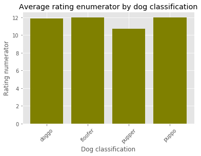

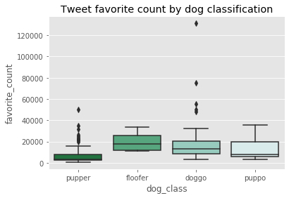

In addition to dog ratings and classifications, we explored other aspects of the WeRateDogs acount. One aspect of interest that was explored is the account level of activity through time, viewed by the frequency of tweets. We saw from the data that the year 2016 had the most tweets with photos at 962 tweets throughout the whole year. By looking at tweets frequency by month, we see that the most tweets with photos were posted in the month of December.